# Iowa Liquor Sales

Jim Lung  
05-15-2018

### Abstract

- The goal of this project is to determine a geographic location (county) in Iowa that will yield the highest amount of liquor sales.
- To use the correlation and forward stepwise regression with linear method are applied to perform predication the bottles sold.
- To obtain the specific trend and predication, the dataset was subset into the highest volume sold location at DES MOINES City in 2017

### Key words

- Liquor Sales,
- Naive Forecast,
- Linear Regression
- Inventory Forecast
- Prediction

### Introduction

- To create a statistical model for the number of bottles sold of liquor which is within the state of Iowa.
- To make informed decisions on inventory prediction, sales, and assist wholesale distributors to plan for the predicted volume of distribution
- Large number of observations are found in Polk County, the city of Des Moines, and the zip code 50010 (Ames, Iowa). Ames is the home of Iowa State
- To set up the range of our analysis to the City of Des Moines in 2017

### Literature review

An Overview of Forecasting Methodology:  
David S. Walonick (1993)

- Trend extrapolation - These methods examine trends and cycles in historical data, and then use mathematical techniques to extrapolate to the future.
- The assumption of all these techniques is that the forces responsible for creating the past, will continue to operate in the future.
- This is often a valid assumption when forecasting short term horizons, but it falls short when creating medium and long term forecasts

### Data Exploration

Achieve the dataset from: https://data.iowa.gov/Economy/Iowa-Liquor-Sales/m3tr-qhgy.

### Data Exploration

- Ensuring bottle size (e.g., 750 ml) x bottles sold = volume liters sold
- Ensuring bottle retail value x bottles sold = sale dollars
- I found no problems with the math, but it was good to check all the same

### Volume of Liquor Category Sales by Gallons Sold

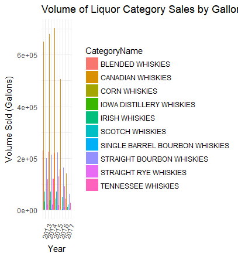

### Volume of Liquor County Sales by Gallons Sold

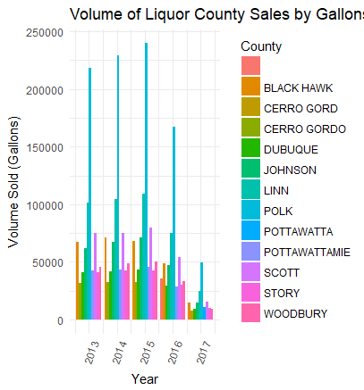

### Dollar sold of Liquor Category

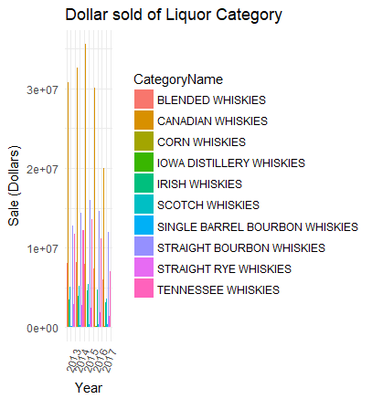

### Gallons Sold for whiskey categories for each City in Polk County

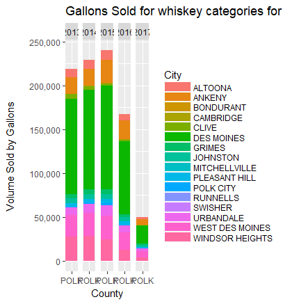

### Build Models

- Build model by selection the highest volume location at DES MOINES City

| Month | Year | City | CategoryName | Bottles Sold | Sale (Dollars) |
| --- | --- | --- | --- | --- | --- |
| 1 | 2017 | DES MOINES | BLENDED WHISKIES | 6.901226 | 35100.55 |
| 1 | 2017 | DES MOINES | CANADIAN WHISKIES | 7.926108 | 112301.42 |
| 1 | 2017 | DES MOINES | CORN WHISKIES | 3.170261 | 948.75 |
| 1 | 2017 | DES MOINES | IOWA DISTILLERY WHISKIES | 1.592121 | 716.73 |
| 1 | 2017 | DES MOINES | IRISH WHISKIES | 6.342434 | 31019.63 |
| 1 | 2017 | DES MOINES | SCOTCH WHISKIES | 6.065074 | 35540.77 |

### Correlation (Model 1)

- model1 <- lm(`Bottles Sold` ~ CategoryName + `Sale (Dollars)`+ `Bottle Volume (ml)`+ `State Bottle Cost`+ `State Bottle Retail`+ `Volume Sold (Gallons)`, data=iowa_data_reduced2)

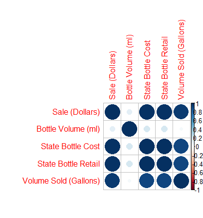

### Correlation (Model 1)

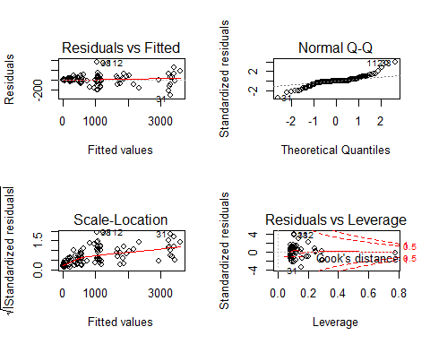

### Correlation (Model 1)

| rn | GVIF | Df | GVIF<sup>1/(2*Df</sup>) | Adjusted_GVIF |
| --- | --- | --- | --- | --- |
| CategoryName | 255.8244 | 9 | 1.360738 | 1.851608e+00 |
| `Sale (Dollars)` | 277.4708 | 1 | 16.657454 | 2.774708e+02 |
| `State Bottle Cost` | 1823143.9656 | 1 | 1350.238485 | 1.823144e+06 |
| `State Bottle Retail` | 1820815.5428 | 1 | 1349.375983 | 1.820816e+06 |

### Forward regression (Model 2)

- forward <- step(lm(`Bottles Sold`~1,data=iowa_data_reduced2),direction = “forward”, scope=~CategoryName +`Sale (Dollars)`+ `Bottle Volume (ml)` +`State Bottle Cost`+`State Bottle Retail`+`Volume Sold (Gallons)`,trace = FALSE)

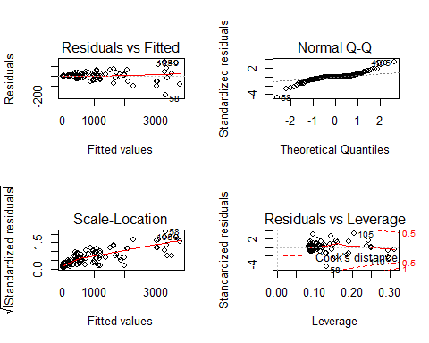

### Forward regression (Model 2)

| rn | GVIF | Df | GVIF<sup>1/(2*Df</sup>) | Adjusted_GVIF |
| --- | --- | --- | --- | --- |
| `Volume Sold (Gallons)` | 60.38886 | 1 | 7.771027 | 60.388858 |
| CategoryName | 391.52906 | 9 | 1.393293 | 1.941265 |
| `State Bottle Retail` | 58.81699 | 1 | 7.669224 | 58.816992 |

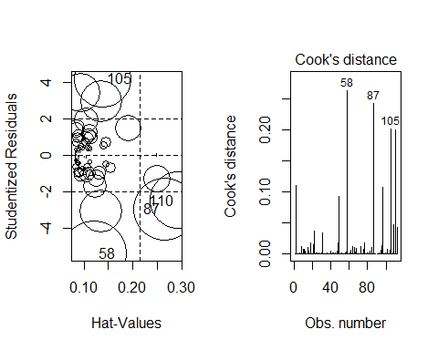

### Model 2 remove influencePlot

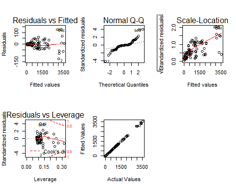

### Bottles Sold Model with Log Transformation (Model 3)

- model3 <- step(lm(log(`Bottles Sold`)~1,data=iowa_data_reduced2),direction = “forward”, scope=~CategoryName +`Sale (Dollars)`+ `Bottle Volume (ml)` +`State Bottle Cost`+`State Bottle Retail`+`Volume Sold (Gallons)`,trace = FALSE)

| rn | GVIF | Df | GVIF<sup>1/(2*Df</sup>) | Adjusted_GVIF |
| --- | --- | --- | --- | --- |
| CategoryName | 6372.52413 | 9 | 1.626862 | 2.646679 |
| `State Bottle Retail` | 50.39835 | 1 | 7.099179 | 50.398346 |
| `Volume Sold (Gallons)` | 56.74351 | 1 | 7.532829 | 56.743511 |
| `Bottle Volume (ml)` | 22.88167 | 1 | 4.783479 | 22.881669 |

### Bottles Sold Model with Log Transformation (Model 3)

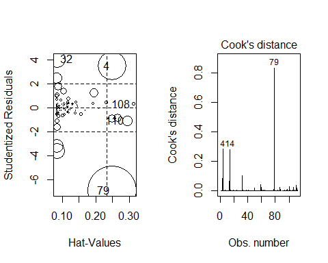

[figure not shown]

### Selection Model

| Models | AIC | BIC | Deviance | df.residual |
| --- | --- | --- | --- | --- |
| Correlation | 1363.90365 | 1401.96263 | 9.928481e+05 | 99 |
| Forward regression | 1079.26792 | 1114.13563 | 1.087422e+05 | 96 |
| Log transformation | -11.08298 | 26.72375 | 4.514541e+00 | 97 |

### Prediction

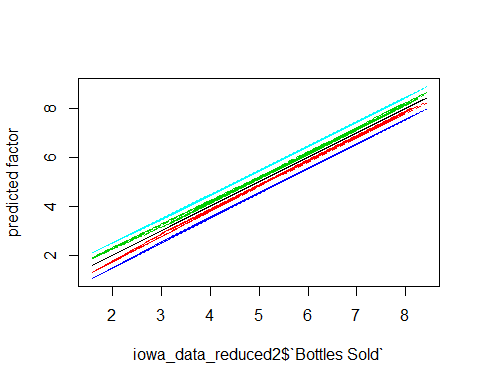